# Real Estate Price Prediction with Machine Learning

Session 3

Associate Professor Ole Maneesoonthorn

Predictive Analytics, Term 4 2020

## Melbourne Real Estate Data

Can we predict the “sold” prices of the real estate property? This data set collates the property prices sold in a certain Melbourne suburb. A portion (not all) of this suburb is part of a well regarded public secondary school zone that is known to generate premium on the sales price.

Our goal is to make use of the predictive analytics toolset to contruct predictions of the real estate sale prices.

**Data description:**

1. Price - sold price of the property, recorded in thousands of Australian dollars
2. Beds - number of bedrooms advertised
3. Baths - number of bathrooms advertised
4. Cars - number of carpark spaces advertised
5. Area - advertised land size in squared metre
6. SchoolZone - Yes/No variable indicating whether the property is located in a sought after school catchment zone
7. Auction - Yes/No variable indicating whether the property was sold through auction
8. New - Yes/No variable indicating whether the property has been built in the past 10 years
9. Subdivided - Yes/No variable indicating whether the property has been subdivided

We will continue our modelling from the workspace saved from Session 1, so that we can compare our new predictive results to the previous models, and use any existing functions that have already been defined.

```r
#Load saved workspace
load('REWorkspace.RData')
```

In this session, we will explore two supervised learning techniques: Regression Tree and Neural Network; and also explore k-means clustering and k-nearest neighbour regression, which are methods under the umbrella of “unsupervised” learning.

### Regression Tree

Let us construct a regression tree model for the real estate price training data. For this, we will be using the “rpart” package.

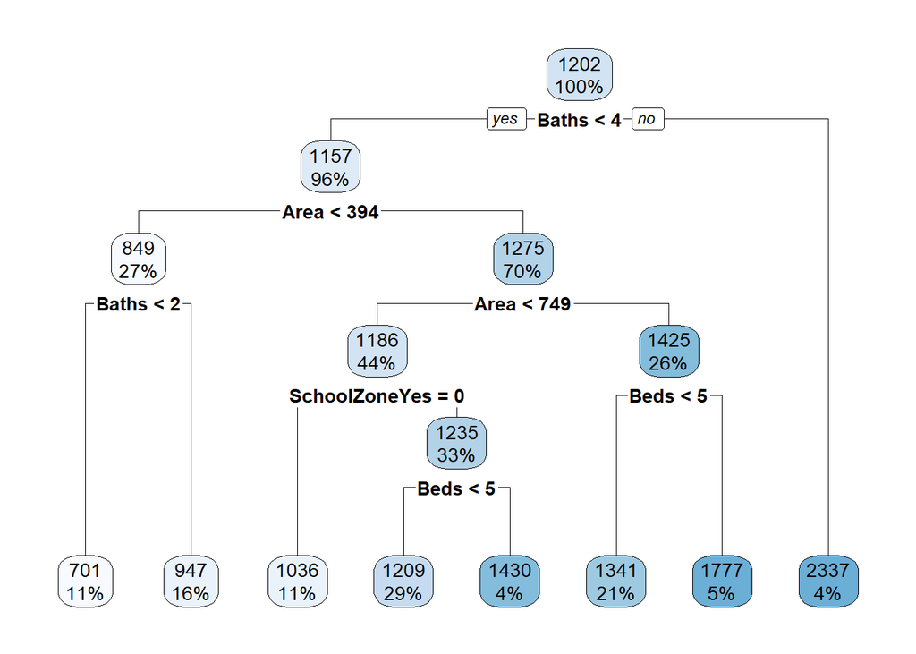

```r
# Load the libraries
# Note rpart.plot enables us to plot the tree visually
library(rpart)
library(rpart.plot)
library(vip)

# Building model
regtree <- rpart(formula = Price ~ ., data    = trainData, method  = "anova")

# Visualizing the tree
rpart.plot(regtree)
```

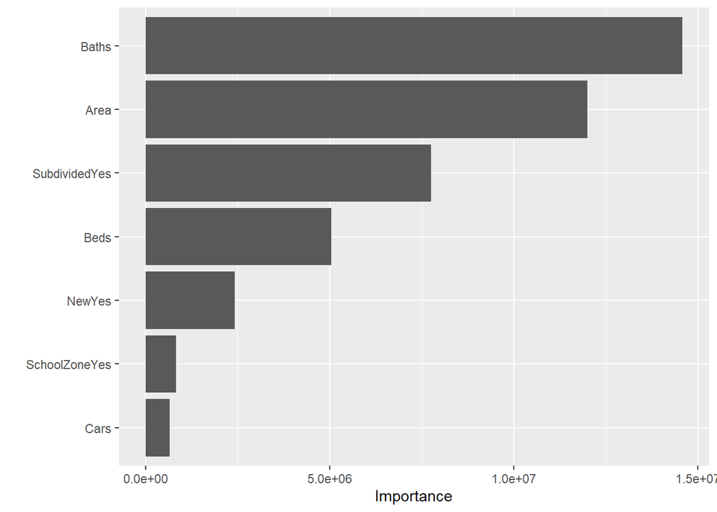

```r
#The summary command gives you detailed information at every level of the tree.
#summary(regtree)

#Variable importance from the tree algorithm
vip(regtree)
```

The tree partitions the data by Baths, Area, Beds and SchoolZone. The other explanatory variables (Cars, New, Subdivision, Auction) have been left out of the final outcome, indicating that they do not determine the final price according to the regression tree algorithm.

The default complexity parameter (cp) is 0.01, which allows for the tree to be as complex as it needs to be. If you desire to reduce the size of the tree, you can “prune” your tree by selecting a larger complexity parameter value. Below is an example of pruning, with cp=0.05 chosen. The pruned tree is now considerably smaller, with the tree partitioning the data only by the number of bathrooms and land area.

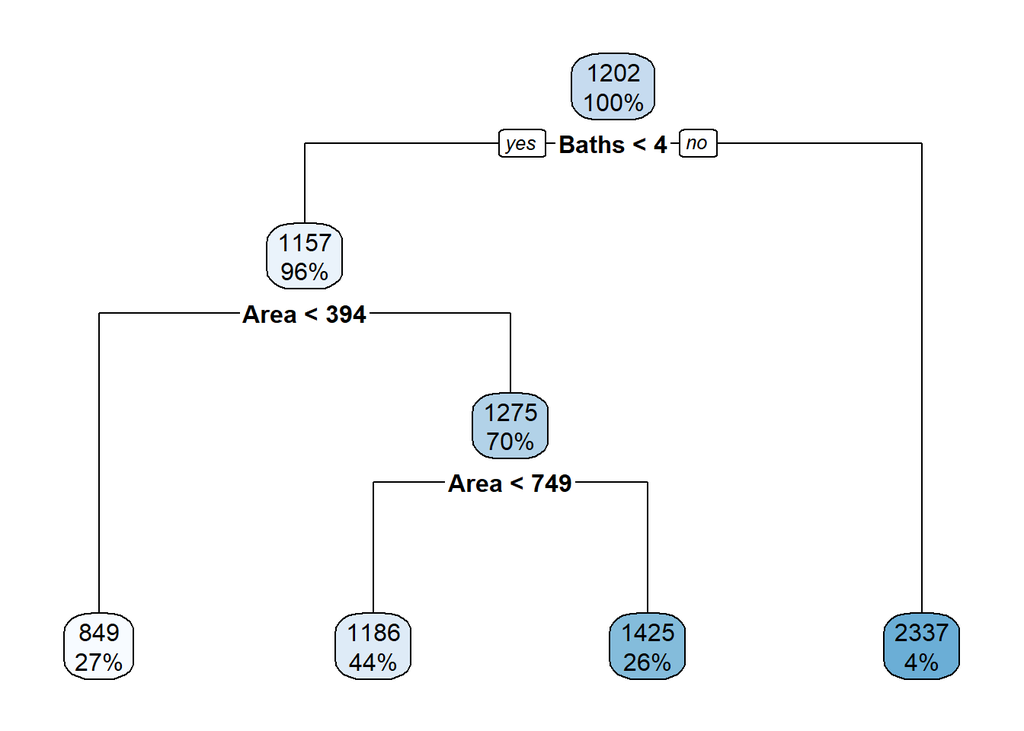

```r
#Pruning tree - complexity coefficient controls the size of the tree
ptree<-prune.rpart(regtree,cp=0.05)
rpart.plot(ptree)
```

**Predicting with Regression Tree**

To predict using the trained regression tree, we simply use the “predict” function and input the model object and the test data characteristics. The function trances the characteristics down the relevant branches of the tree, and give the prediction based on the segment mean. We conduct the prediction using the larger tree.

```r
# prediction
y_regtree<- predict(regtree, newdata = testData)
head(y_regtree)
```

```
##        3       12       15       19       28       44
## 1209.442 1036.464 1209.442 1341.491 1341.491  701.250
```

The predictive accuracy statistics can be computed in the usual way, as in the case of the regression predictions.

```r
# Assessing model
stats_regtree=cbind(csaccuracy(testData[,"Price"],y_regtree,mean(trainData[,"Price"])),
                    Banker=banker(testData[,"Price"]-y_regtree),
                    REAgent=agent(testData[,"Price"]-y_regtree,testData[,"Price"]))
stats_regtree
```

```
##         RMSE      MAE     MAPE     MASE   Banker  REAgent
## [1,] 305.524 212.4015 16.75901 0.676377 306.1961 109.8886
```

The regression tree is certainly predicting better than the naive sample mean, with MASE of 0.676. However, by other metrics, it does considerably worse than the standard regression methods, including in terms of the Banker and Real Estate Agent’s losses.

### Neural Network

There are several packages that can train neural networks, including “nnet”. We will be using the package “neuralnet” here. Unlike “nnet”, “neuralnet” can train networks with more than one hidden layers, and so it is more flexible.

**Building the Neural Network**

Before fitting the neural network, we will need to rescale the data and convert them into numeric values. Note that the scale() function rescales the data to have zero mean and unit variance and effectively calculates the z-score of each observation. We only do this for numerical variables, and all dummy variables are left as 0/1 records. Once the data is rescaled, we split the data into the training and test sets again using the same random number as the original split.

```r
library(neuralnet)

# scaled first five numeric data
# do not scale the dummy variables
realestate_scaled <- realestate
for(i in 1:5){
  realestate_scaled[,i]=as.numeric(scale(realestate[,i]))
}

# creating training and test set using the same random data partition as before
trainData_scaled <- realestate_scaled[train_index,]
testData_scaled <- realestate_scaled[-train_index,]
```

Now that the data is rescaled, we can build the neural network model. Note that in the following code, a random number seed has been set. This is because the neural network algorithm starts out at a randomly sampled weights, and relies on an optimization algorithm called the “stochastic gradient descent”, which also involves some simulation. Thus, each time you run the algorithm, you will get different results. To keep the results stable for analysis, a random seed needs to be fixed.

The model below contains one hidden layer, with 4 nodes assigned to that hidden layer. Generally speaking, the more nodes/layers, the lower the error will be - not different to the context of multiple regression with more predictors. However, a larger (and deeper) network takes longer to train, and tends to be unstable. That is, the result is affected greatly by the sequence of random number used in the optimization algorithm. Unless the data is large and contains strong signals, it is best to train a smaller network.

```r
# Building model
#Set the random seed to make the results static
set.seed(321)
NN <- neuralnet(formula = Price ~., data=trainData_scaled, hidden = 4)
```

**Network Visualization and Further Analysis**

You can construct a visualization of the network with “neuralnet”. However, the visualization is not ideal when you have sizable networks. The visualization prints all weights on the plot, but they are not legible except if your network is rather small.

The package “NeuralNetTools” provide a toolset for visualization and further analysis that are applicable to models built using either the “nnet” or “neuralnet” packages. The network plot generated from this package is colour coded, with grey lines indicating negative weights, while the black lines indicate positive weights. The size of the lines indicate the magnitude of the weights, with thick lines indicating larger magnitude.

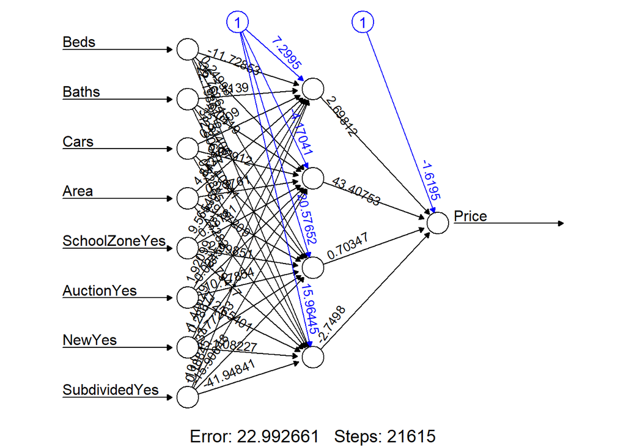

```r
#Visualization of the neural network
#neuralnet allows you to plot the network
plot(NN,rep="best")
```

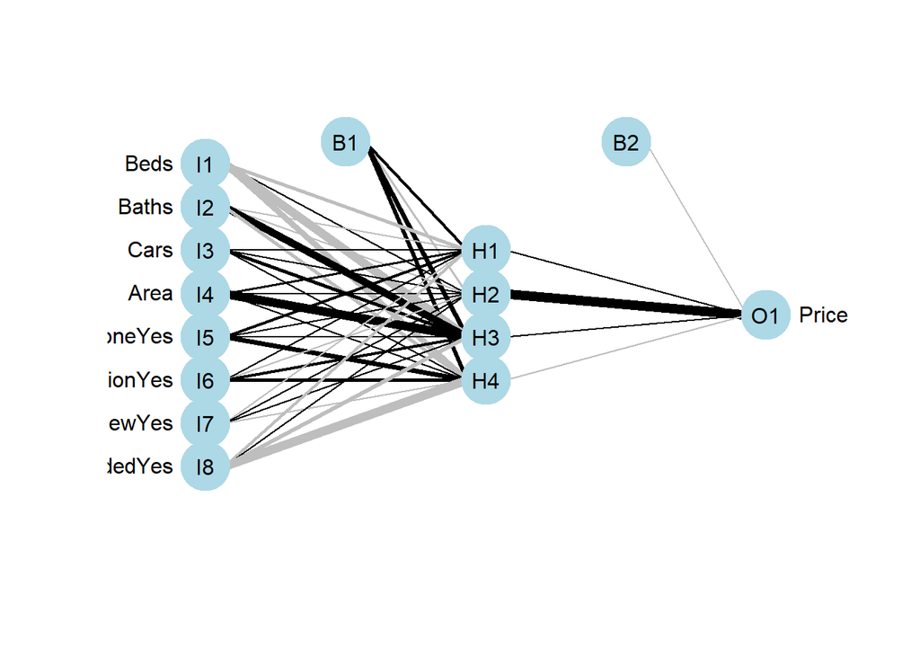

```r
#... But the plot is difficult to read
#Let us use the toolset from "NeuralNetTools"
library(NeuralNetTools)
plotnet(NN)
```

The “NeuralNetTools” package also provide analysis tools for the neural network, including variable importance by both the Garson and Olden methods, as well as the sensitivity analysis via Lek Profile.

As described in the lecture notes, the Garson method summarises variable importance in terms of absolute magnitude of weights of each input variable relative to the other variables. When assessing the plot, the variables are ranked from least important to most important on the horizontal axis.

The Olden method takes the sum product of the weights for each variable, and thus the overall sign is retained. However, if the weights at each layer are of different signs, they will cancel out. So when the Olden coefficient is close to zero, it does not necessarily imply that the variable has no impact within the network.

From Garson plot below, we can see that the variables that are deemed important by the neural network are Beds, Subdivided, SchoolZone and Area. From the Olden plot, the three most important variables are Subdivided, Baths and Area. These variable importance analysis need to be used with care, as the magnitude of weights are sensitive to the data scale and the link functions used within the network.

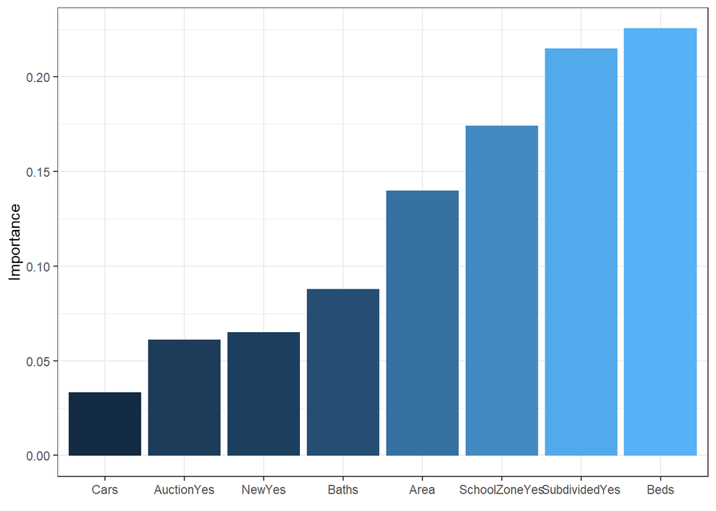

```r
#variable importance
#two different methods to look at them
garson(NN)
```

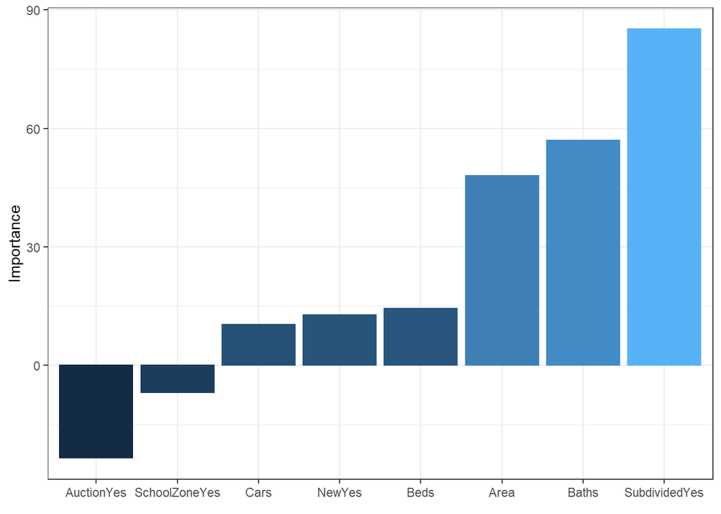

```r
olden(NN)
```

Another useful tool is the sensitivity analysis using Lek profile. This tool allows you to gauge the (potentially nonlinear) relationship implied by the neural network, using predictions. For a given input variable, the function plots the predicted value of the outcome variable over a sequence of values covering the data range while keeping the other input variables fixed at particular values.

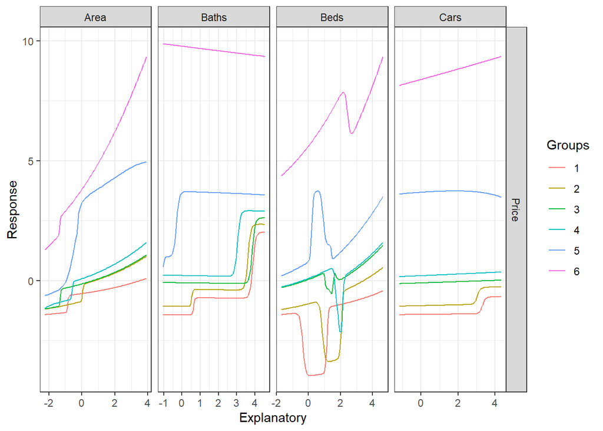

```r
#sensitivity analysis
#by default quantiles
lekprofile(NN,xsel=c('Beds','Baths','Cars','Area'))
```

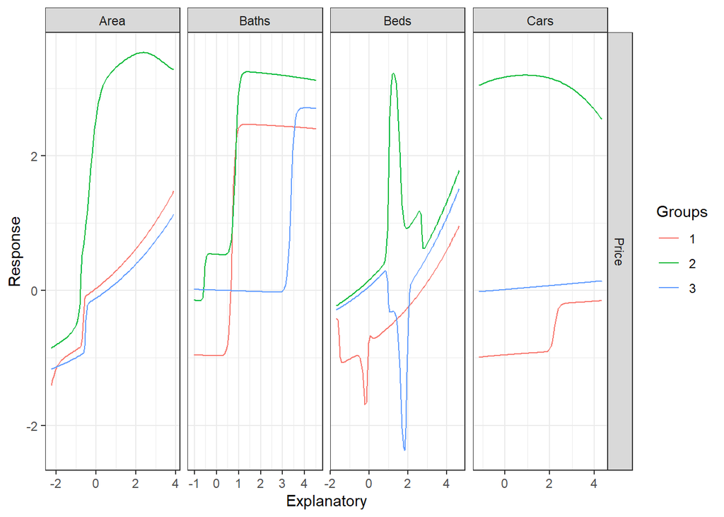

```r
#by clusters - group data into 3 clusters
set.seed(321)
lekprofile(NN,xsel=c('Beds','Baths','Cars','Area'),group_val=3)
```

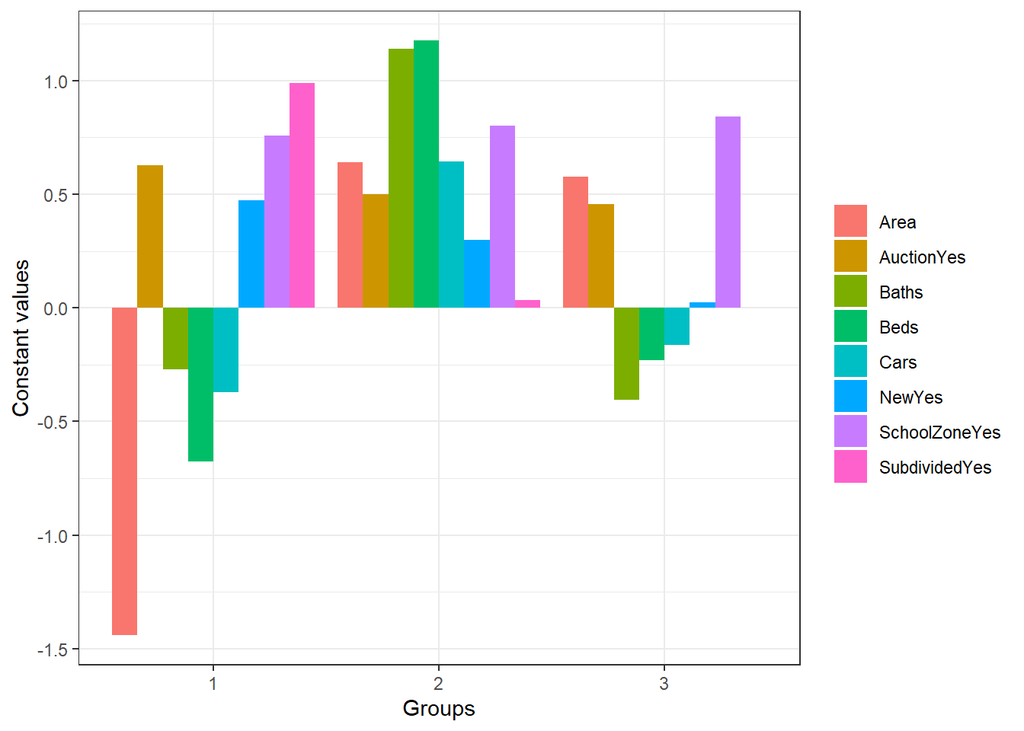

```r
#Reveal the characteristics of the clusters
set.seed(321)
lekprofile(NN,xsel=c('Beds','Baths','Cars','Area'),group_val=3,group_show=TRUE)
```

In this particular case, the clutering method provide a natural interpretation of property type, so I provide below the analyses from the Lek profile plots based on 3 clustering groups:

- The cluster group characteristics reveal that properties in group 1 are all subdivided properties. Group 2 are full section properties that tend of have more bedrooms, bathrooms and advertised carspaces, i.e. larger homes (but not larger land area), compared to group 3.
- Area has a nonlinear relationship with price, and the relationship varies depending on the type of property. Group 1 and group 3 have similar pattern, with an increase in land area having largest premium around the average point. The greatest land size premium is observed in group 2 (i.e. for larger homes in full section properties).
- The number of bathrooms have positive impact, but with the incremental impact kicking in at different levels. The large positive impact for group 3 happens at higher value of bathroom.
- The number of bedrooms seems to have accelerating positive impact on the property price, with some irregularities in the relationship for groups 2 and 3.
- The number of car spaces does not have much of an impact on groups 2 and 3, but have a step-like positive impact on group 1.

**Predicting with the Neural Network**

In R, it is relatively simple to obtain the prediction from the neural network using the “predict” function. It is important, however, to remember that we have constructed the network using rescaled data (i.e. z-scores), so we will need to reverse the process to obtain predictions in the data unit. This is simply done by multiplying the standard deviation and adding back the mean. If you notice the prediction to property ID 44, the neural network returns a negative price prediction. This is one of the pitfalls of neural network - that predictions can sometimes be non-sensible in the problem context.

```r
#Predicting with neural network
y_NN <- predict(NN, newdata = testData_scaled)
head(y_NN)
```

```
##          [,1]
## 3  -0.2254059
## 12 -1.2352349
## 15 -0.1202781
## 19  0.2327354
## 28  0.1679327
## 44 -3.1705877
```

```r
# convert predicted y into  original unit
y_NN <- y_NN*sd(trainData[,"Price"]) + mean(trainData[,"Price"])
head(y_NN)
```

```
##          [,1]
## 3  1111.55661
## 12  706.65553
## 15 1153.70863
## 19 1295.25294
## 28 1269.26968
## 44  -69.34361
```

The real test of the model for predictive purposes is, of course, in its predictive accuracy when assessed on the test data. Complicated as it may be, with all of its potential for capturing complex nonlinear patterns, the neural network does badly compared to the simpler regression model with this particular predictive problem for property prices.

```r
# Assessing model
stats_NN=cbind(csaccuracy(testData[,"Price"],y_NN,mean(trainData[,"Price"])),
                    Banker=banker(testData[,"Price"]-y_NN),
                    REAgent=agent(testData[,"Price"]-y_NN,testData[,"Price"]))

#Gathering the predictive accuracy statistics
allstats=rbind(allstats[1:3,],RegTree=stats_regtree,NeuralNet=stats_NN)
rownames(allstats)[4:5]=c('RegTree','NeuralNet')
allstats
```

```
##               RMSE      MAE     MAPE      MASE   Banker   REAgent
## Linear    296.3371 185.7684 13.88486 0.5915656 259.7297  75.43717
## Stepwise  295.6283 186.3040 13.93978 0.5932714 260.2968  77.58615
## Nonlinear 280.5423 175.7471 13.38706 0.5596538 245.3497  80.46086
## RegTree   305.5240 212.4015 16.75901 0.6763770 306.1961 109.88861
## NeuralNet 393.6379 247.6763 18.43003 0.7887069 353.7975 125.99764
```

## Unsupervised Learning

### K-means clustering

In this section, we explore the first of the unsupervised learning methods: k-means clustering. In unsupervised learning, the main objective is to partition the data by “similarities”, without using the output variable. The k-means clustering method partition data by similarities in their means.

**Selecting the number of clusters**

Before we get the ball rolling with the analysis, we need to decide how many clusters, “K”, we would use. There are three tools that may help you with this decision, using a function from the “factoextra” package.

The simplest and arguably the most popular method is the “Elbow” method. This method involves plotting the total within-cluter sum of square (WCSS) against the number of clusters “K”. Naturally, the more clusters we use, the smaller the WCSS, just like the case of regression where the sum of squared error is smaller with every input variable you add (even if it is not useful). There will be a greater degree of WCSS reduction at lower “K” values - the law of diminishing return! The Elbow method looks for the kink in the WCSS curve, with the optimal “K” being when the curve flattens, indicating an additional cluster does not add much value.

In this particular case of property prices, the elbow bend is not sharp and clear cut. Some judgement is needed here to choose an optimal “K”. My choice is to try K=6 here as that is when there is a significant change in slope. Some may argue for K=3 here as well. It is important to note that all of these preliminary analysis, as well as the clustering algorithm itself should be run WITHOUT the output variable “Price”.

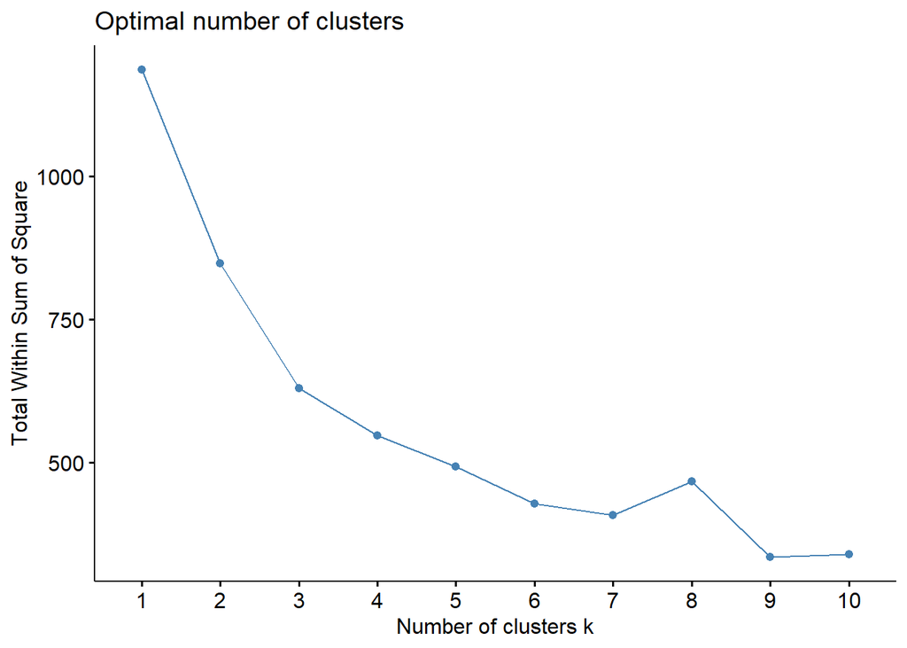

```r
library(factoextra)
# select optimal number of clusters based 3 methods
#Elbow method - where is the kink?
fviz_nbclust(trainData_scaled[-1], kmeans, method = "wss")
```

The second method is called the Gap Statistic, which measures the distance between having K clusters, and having no clustering at all (assuming that the data is evenly scattered over the space). So we want the gap to be as high as possible, subject to the standard error of the statistic, but at the same time not too many clusters. So the optimal rule is to select the smallest K such that

$$Gap(K) \geq Gap(K+1)-Std.Error.$$
According to the gap plot below, the optimal is to only have one cluster. However, if you want at least two distinct clusters, the optimal would be K=4.

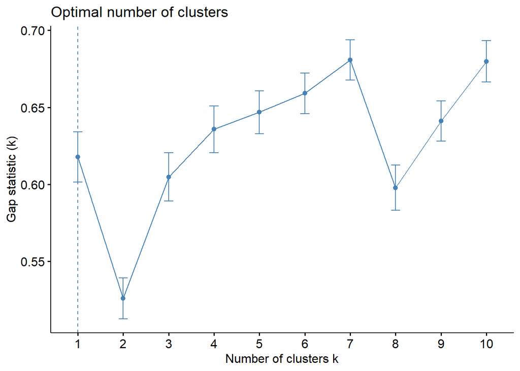

```r
#Gap stat method
fviz_nbclust(trainData_scaled[-1], kmeans, method = "gap_stat")
```

The third method is the Silhouette method. The Silhouette coefficient measures how similar the observations are to the other observations in the same cluster, relative to the observations that belong to other clusters. Thus, the optimal choice of K would be one that maximizes the Silhouette coefficient. For this property pricing case, the Silhouette suggests an optimal K=3.

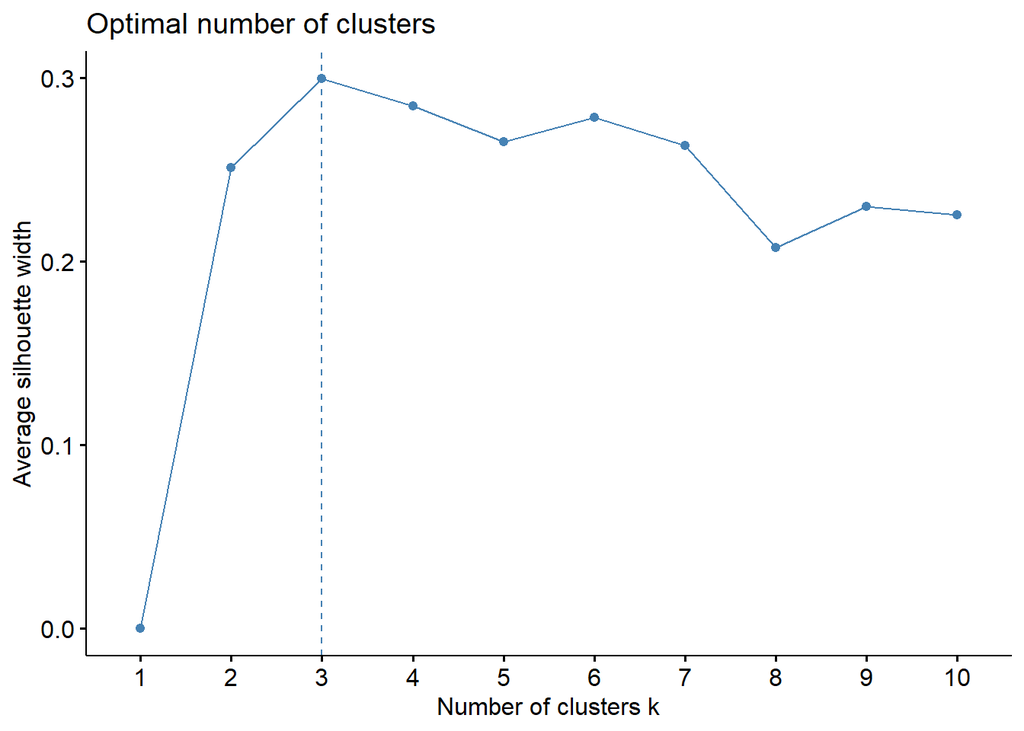

```r
#Silhouette method
fviz_nbclust(trainData_scaled[-1], kmeans, method = "silhouette")
```

**Obtaining the optimal clusters**

Let us proceed with the choice of K=6 that is suggested by the Elbow method. I have made this decision for the larger choice of K here since our aim here is to obtain predictions from these clustering, and the larger K implies more granularity in your prediction (the same case as regression trees, where you get more granular prediction with a larger tree).

The k-means cluster training below has six clusters, with the smallest cluster containing 15 observations (5.7%) and the largest cluster containing 76 (28.9%) observations of the training data. Note that each time you run the clustering algorithm, the cluster “labels” (i.e. numbering of 1 to 6) may change, but the final grouping and cluster characteristics unique to each group would remain unchanged. As with any other grouping context, the numeric label of the cluster does not contain any information, they simply serve as labels for identification. I have fixed the random seed here so that the labels remain static for your purpose of replication.

```r
# only select numerical variables
# set the number of cluster at 6 based on the Elbow method discussed above
# The input nstart is the number of random sets to start with when initializing the algorithm
set.seed(123)
km <- kmeans(trainData_scaled[-1], centers = 6, nstart = 25)
#number of obs per cluster
km$size
```

```
## [1] 76 15 53 39 33 47
```

```r
#cluster membership in percentage
(km$size/nrow(trainData))*100
```

```
## [1] 28.897338  5.703422 20.152091 14.828897 12.547529 17.870722
```

The “factoextra” package also provide a visualization tool for the trained cluster itself. Rather than constructing a multi-dimension plot, the function uses a dimension reduction technique (Principle Component Analysis or PCA) to reduce the data down to two common factors and depict the clustering based on them. Our visualization of the cluster show distinct clusters based on the two common factor.

Despite being visually appealing, the visualization does not lend itself to much interpretation in the context of the problem. The centroid statistics give a much better picture of what attributes are common in each cluster.

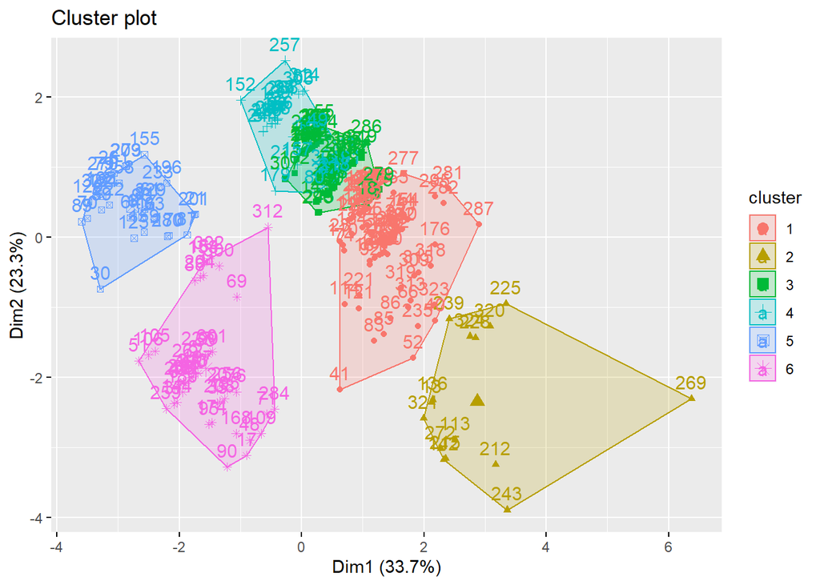

```r
# visualizing the result
fviz_cluster(km, data = trainData_scaled[-1])
```

Looking at the statistics by cluster, we can see that two of the clusters (clusters 5 and 6 as labeled below) mainly consists of subdivided properties. Cluster 6, however tend to be larger in land and dwelling size (with more beds, baths and car spaces), and tend to be those that are newly built compared to Cluster 5. Clusters 3 and 4 are very similar in characteristics, they are older full section properties with an average of 3 bedrooms. The only distinguishing factor between these two clusters is that all properties in group 4 have one carspace. Clusters 1 and 2 are full section properties that are larger in dwelling sizes, with more beds and baths. The majority (60%) of properties in cluster 2 are built within the last ten years.

```r
# Mean for each cluster
cl_stats=aggregate(trainData, by=list(cluster=km$cluster), mean)
cl_stats
```

| cluster | Price | Beds | Baths | Cars | Area | SchoolZoneYes | AuctionYes | NewYes | SubdividedYes |
| --- | --- | --- | --- | --- | --- | --- | --- | --- | --- |
| 1 | 1350.6447 | 4.342105 | 2.328947 | 2.039474 | 754.3289 | 0.8289474 | 0.4868421 | 0.13157895 | 0.0000000 |
| 2 | 2124.6000 | 5.133333 | 4.066667 | 3.000000 | 780.1333 | 0.8000000 | 0.4666667 | 0.60000000 | 0.0000000 |
| 3 | 1186.7358 | 3.150943 | 1.320755 | 2.113208 | 746.0377 | 0.8113208 | 0.4716981 | 0.00000000 | 0.0000000 |
| 4 | 1217.3077 | 3.179487 | 1.487179 | 1.000000 | 741.6923 | 0.8717949 | 0.4615385 | 0.00000000 | 0.0000000 |
| 5 | 723.1212 | 2.393939 | 1.090909 | 1.181818 | 284.7273 | 0.7272727 | 0.5454545 | 0.03030303 | 1.0000000 |
| 6 | 1007.5745 | 3.404255 | 2.148936 | 1.872340 | 327.5319 | 0.7659574 | 0.6595745 | 0.80851064 | 0.9787234 |

K-means clustering was designed as characteristic exploration tool, and due to its “unsupervised” nature does not naturally produce predictions per se. Thus, it is up to the analyst to make a call on how k-means clustering can be used to predict the outcome variable. I have provided two options in class, and we will explore them here.

**Predicting with cluster mean**

The simplest way of predicting with k-means is to take the cluster mean statistics and use them as the prediction. This involves applying the clustering to the new observation’s input variables and predict which cluster the observation most likely belong to. The algorithm ultimately chooses the cluster that is the shortest distance (collectively) from the observation. Once the predicted cluster membership is obtained, we then use the mean of the output variable from that cluster as the predicted value. The code block below goes through this process.

Note that in our case, because we assign six clusters, there are potentially six unique predictive values. As you can see, you will lose granularity in the prediction with lesser number of clusters. So it is not surprising that this method does not perform well in prediction in any metrics that we calculate here, although it still performs better than the neural network.

```r
# Prediction with sample mean
library(clue)
#First predict the cluster that each row of the test data most likely belong
test_cl=as.integer(cl_predict(km, newdata = testData_scaled[-1]))
#Match the cluster classification with the test set data ID and actual observation
c_km=data.frame(id=as.integer(rownames(testData)),actual=testData$Price,cl=test_cl)
#Look up the mean of the prices for each cluster, and match it to the predicted classification
y_km=merge(c_km, cl_stats[1:2],by.x="cl",by.y="cluster")


#Calculate predictive accuracy metrics
stats_km=cbind(csaccuracy(y_km$actual,y_km$Price,mean(trainData[,"Price"])),
                    Banker=banker(y_km$actual-y_km$Price),
                    REAgent=agent(y_km$actual-y_km$Price,y_km$actual))
stats_km
```

```
##          RMSE      MAE     MAPE      MASE   Banker  REAgent
## [1,] 357.7008 236.2117 18.42448 0.7521987 348.1406 121.5825
```

**Predicting with cluster specific regression**

K-means clustering can be used as a “pre-filter” to other supervised learning techniques. That is, use k-means clustering to partition data into similar subgroups and apply supervised learning to each of the subgroups. In this pricing example, we use the regression model as a predictive tool after using k-means clustering for data partition. Unfortunately, there is no packages that readily does this, and we write a function for this purpose below.

```r
#Prediction with cluster specific regression

#A function to fit and calculate the predicted value for each cluster.
#You will need to make sure that any input variables that may cause multicolinearity
#in the regression in each cluster are removed.
kmWithReg<-function(kmobj,train,test,testcl){
  for(i in 1:max(kmobj$cluster)){
    #Extract training data for each cluster
    dat=train[(kmobj$cluster==i),]
    #Fit regression model for that cluster
    #Change the name of your output variable here.
    #You can also change the model specification.
    regfit=lm(Price~.,data=dat)
    #Extract the relevant test data for this cluster
    newdat=test[(testcl==i),]
    #Predict using the fitted regression model
    pred=predict(regfit,newdata=newdat)
    #save the outputs
    saved=data.frame(id=as.integer(rownames(newdat)),
                      actual=newdat$Price,predicted=pred)
    if(i==1){
      yhat=saved
    }else{

      yhat=rbind(yhat,saved)
    }
  }
  return(yhat)
}
```

As mentioned in class, each cluster needs to have adequate number of observations for the predictive regression model to be credible. So I have considered K=2,3,…,6 in this technique, but it turns out that the predictive result for K=2 is the best.

The clustering results for K=2 in this case indicate that 100% of the observations one of the subgroups are full section, while 99% of the properties in the other subgroup are subdivided. This suggest that the fact that a property is subdivided is an almost perfect discriminating factor between the two clusters. Technically, this also indicate that if the subdivision dummy variable is included in a regression model for each of the subgroup, it will cause multicolinearity issues. Thus, we remove this variable when we call the “kmWithReg” function. The predictive accuracy statistics reveal that this method is certainly much better than using the k-means with sample means. It is also an improvement to the multiple linear regression, but perform slightly worse than the nonlinear regression model.

```r
#Reduce the number of clusters to make sure we have adequate observations per cluster
km4reg=kmeans(trainData_scaled[-1], centers = 2, nstart = 25)

# Mean for each cluster
cl_stats2=aggregate(trainData, by=list(cluster=km4reg$cluster), mean)
cl_stats2
```

| cluster | Price | Beds | Baths | Cars | Area | SchoolZoneYes | AuctionYes | NewYes | SubdividedYes |
| --- | --- | --- | --- | --- | --- | --- | --- | --- | --- |
| 1 | 1338.1967 | 3.814208 | 2.0000 | 1.918033 | 751.3497 | 0.8306011 | 0.4754098 | 0.1038251 | 0.0000 |
| 2 | 890.2375 | 2.987500 | 1.7125 | 1.587500 | 309.8750 | 0.7500000 | 0.6125000 | 0.4875000 | 0.9875 |

```r
# Obtaining the predictive cluster for the test data
test_cl2=as.integer(cl_predict(km4reg, newdata = testData_scaled[-1]))

#Remove the variable "Subdivision" from the data set, as it is the perfect discriminator of the clusters, and will cause multicolinearity issues in regression.
kmreg=kmWithReg(km4reg,trainData[,-9],testData[,-9],test_cl2)

#Calculating the predictive accuracy statistics
stats_kmreg=cbind(csaccuracy(kmreg$actual,kmreg$predicted,mean(trainData[,"Price"])),
                    Banker=banker(kmreg$actual-kmreg$predicted),
                    REAgent=agent(kmreg$actual-kmreg$predicted,kmreg$actual))

#Gathering predictive accuracy statistics
allstats=rbind(allstats[1:5,],stats_km,stats_kmreg)
rownames(allstats)[6:7]=c('kMeans','kMeansReg')
allstats
```

```
##               RMSE      MAE     MAPE      MASE   Banker   REAgent
## Linear    296.3371 185.7684 13.88486 0.5915656 259.7297  75.43717
## Stepwise  295.6283 186.3040 13.93978 0.5932714 260.2968  77.58615
## Nonlinear 280.5423 175.7471 13.38706 0.5596538 245.3497  80.46086
## RegTree   305.5240 212.4015 16.75901 0.6763770 306.1961 109.88861
## NeuralNet 393.6379 247.6763 18.43003 0.7887069 353.7975 125.99764
## kMeans    357.7008 236.2117 18.42448 0.7521987 348.1406 121.58255
## kMeansReg 285.6843 182.0347 13.63729 0.5796760 253.9720  75.95538
```

### K-Nearest Neighbour (k-nn)

```r
#Loading the library
library(caret)
#Let's look at how well the knn regression fits the training data - use scaled data here
#Remember you need to remove the output variable to train k-nn (unsupervised)
knn_fit <- knnreg(x = trainData_scaled[, -1] , y = trainData_scaled[,"Price"] ,
                   k = as.integer(sqrt(nrow(trainData))))
```

Again, the real test is in its test set predictive accuracy. We obtain the test set predictions and calculate the predictive accuracy metrics below. Remember that we construct the predictions using the scaled data, so we need to convert these predictions to the raw data unit manually.

```r
#Don't forget to convert the predictions back to raw data unit when obtaining predictions
y_knnm <- predict(knn_fit,testData_scaled[,-1])
y_knnm<-y_knnm*sd(trainData[,"Price"])+mean(trainData[,"Price"])
#Compute predictive accuracy metrics for k-nn
stats_knn <- cbind(csaccuracy(testData[,"Price"],y_knnm,mean(trainData[,"Price"])),
                    Banker=banker(testData[,"Price"]-y_knnm),
                    REAgent=agent(testData[,"Price"]-y_knnm,testData[,"Price"]))

#Gathering predictive accuracy statistics
allstats=rbind(allstats[1:7,],stats_knn)
rownames(allstats)[8]='knn'
allstats
```

```
##               RMSE      MAE     MAPE      MASE   Banker   REAgent
## Linear    296.3371 185.7684 13.88486 0.5915656 259.7297  75.43717
## Stepwise  295.6283 186.3040 13.93978 0.5932714 260.2968  77.58615
## Nonlinear 280.5423 175.7471 13.38706 0.5596538 245.3497  80.46086
## RegTree   305.5240 212.4015 16.75901 0.6763770 306.1961 109.88861
## NeuralNet 393.6379 247.6763 18.43003 0.7887069 353.7975 125.99764
## kMeans    357.7008 236.2117 18.42448 0.7521987 348.1406 121.58255
## kMeansReg 285.6843 182.0347 13.63729 0.5796760 253.9720  75.95538
## knn       327.9338 206.0074 15.42880 0.6560154 281.2654  98.40100
```

Don’t forget to save the workspace for later use!

```r
#Save the workspace
save.image("REPriceSession3.RData")
```

**Key takeaway: There are multiple tools designed to conduct the analysis of each method. For example, there are two ways to look at the variable importance in neural network; there are three tools you can use to choose the optimal number of clusters in k-means clustering. Each tool has its own advantage and also its own flaws. Use them with discretion, and keep in mind the context of your analytics problem.**